## Importing necessary libraries

```python
import numpy as np
import pandas as pd
import matplotlib.pyplot as plt
import seaborn as sns
import warnings

# Ignore all DeprecationWarnings
warnings.filterwarnings("ignore")
```

## Reading the data

```python
df = pd.read_csv("C:/Users/Shreshtha/Downloads/archive/Myntra Fasion Clothing.csv")
df
```

|  | URL | Product_id | BrandName | Category | Individual_category | category_by_Gender | Description | DiscountPrice (in Rs) | OriginalPrice (in Rs) | DiscountOffer | SizeOption | Ratings | Reviews |
| --- | --- | --- | --- | --- | --- | --- | --- | --- | --- | --- | --- | --- | --- |
| 0 | https://www.myntra.com/jeans/roadster/roadster... | 2296012 | Roadster | Bottom Wear | jeans | Men | roadster men navy blue slim fit mid rise clean... | 824.0 | 1499.0 | 45% OFF | 28, 30, 32, 34, 36 | 3.9 | 999.0 |
| 1 | https://www.myntra.com/track-pants/locomotive/... | 13780156 | LOCOMOTIVE | Bottom Wear | track-pants | Men | locomotive men black white solid slim fit tra... | 517.0 | 1149.0 | 55% OFF | S, M, L, XL | 4.0 | 999.0 |
| 2 | https://www.myntra.com/shirts/roadster/roadste... | 11895958 | Roadster | Topwear | shirts | Men | roadster men navy white black geometric print... | 629.0 | 1399.0 | 55% OFF | 38, 40, 42, 44, 46, 48 | 4.3 | 999.0 |
| 3 | https://www.myntra.com/shapewear/zivame/zivame... | 4335679 | Zivame | Lingerie & Sleep Wear | shapewear | Women | zivame women black saree shapewear zi3023core0... | 893.0 | 1295.0 | 31% OFF | S, M, L, XL, XXL | 4.2 | 999.0 |
| 4 | https://www.myntra.com/tshirts/roadster/roadst... | 11690882 | Roadster | Western | tshirts | Women | roadster women white solid v neck pure cotton ... | NaN | 599.0 | 35% OFF | XS, S, M, L, XL | 4.2 | 999.0 |
| ... | ... | ... | ... | ... | ... | ... | ... | ... | ... | ... | ... | ... | ... |
| 526559 | https://www.myntra.com/sweaters/hm/hm-women-be... | 16929990 | H&M | Western | sweaters | Women | hm women beige oversized cashmere jumper | NaN | 9999.0 | NaN | XS, S, M, L | NaN | NaN |
| 526560 | https://www.myntra.com/jackets/hm/hm-women-bla... | 16026012 | H&M | Western | jackets | Women | hm women black water repellent parka jacket | NaN | 9999.0 | NaN | XS, S, M, L, XL | NaN | NaN |
| 526561 | https://www.myntra.com/dresses/250-designs/250... | 17654114 | 250 DESIGNS | Western | dresses | Women | 250 designs blue lace sheath dress | NaN | 9999.0 | NaN | S, M, L, XL, XXL | NaN | NaN |
| 526562 | https://www.myntra.com/dresses/masaba/masaba-w... | 12508700 | Masaba | Western | dresses | Women | masaba women yellow printed a line dress | NaN | 9999.0 | NaN | XS, S, M, L, XL | NaN | NaN |
| 526563 | https://www.myntra.com/tshirts/jockey/jockey-w... | 17856544 | Jockey | Western | tshirts | Women | jockey women blue extended sleeves t shirt | NaN | 799.0 | NaN | S, M, L | NaN | NaN |

526564 rows × 13 columns

By looking at the data, we know that the URL and Product ID are not relevant for model building. So we first drop these 2 variables from our dataset.

### Dropping irrelevant columns

```python
drop_cols = ['URL', 'Product_id']
df.drop(columns=drop_cols, inplace=True)
df
```

|  | BrandName | Category | Individual_category | category_by_Gender | Description | DiscountPrice (in Rs) | OriginalPrice (in Rs) | DiscountOffer | SizeOption | Ratings | Reviews |
| --- | --- | --- | --- | --- | --- | --- | --- | --- | --- | --- | --- |
| 0 | Roadster | Bottom Wear | jeans | Men | roadster men navy blue slim fit mid rise clean... | 824.0 | 1499.0 | 45% OFF | 28, 30, 32, 34, 36 | 3.9 | 999.0 |
| 1 | LOCOMOTIVE | Bottom Wear | track-pants | Men | locomotive men black white solid slim fit tra... | 517.0 | 1149.0 | 55% OFF | S, M, L, XL | 4.0 | 999.0 |
| 2 | Roadster | Topwear | shirts | Men | roadster men navy white black geometric print... | 629.0 | 1399.0 | 55% OFF | 38, 40, 42, 44, 46, 48 | 4.3 | 999.0 |
| 3 | Zivame | Lingerie & Sleep Wear | shapewear | Women | zivame women black saree shapewear zi3023core0... | 893.0 | 1295.0 | 31% OFF | S, M, L, XL, XXL | 4.2 | 999.0 |
| 4 | Roadster | Western | tshirts | Women | roadster women white solid v neck pure cotton ... | NaN | 599.0 | 35% OFF | XS, S, M, L, XL | 4.2 | 999.0 |
| ... | ... | ... | ... | ... | ... | ... | ... | ... | ... | ... | ... |
| 526559 | H&M | Western | sweaters | Women | hm women beige oversized cashmere jumper | NaN | 9999.0 | NaN | XS, S, M, L | NaN | NaN |
| 526560 | H&M | Western | jackets | Women | hm women black water repellent parka jacket | NaN | 9999.0 | NaN | XS, S, M, L, XL | NaN | NaN |
| 526561 | 250 DESIGNS | Western | dresses | Women | 250 designs blue lace sheath dress | NaN | 9999.0 | NaN | S, M, L, XL, XXL | NaN | NaN |
| 526562 | Masaba | Western | dresses | Women | masaba women yellow printed a line dress | NaN | 9999.0 | NaN | XS, S, M, L, XL | NaN | NaN |
| 526563 | Jockey | Western | tshirts | Women | jockey women blue extended sleeves t shirt | NaN | 799.0 | NaN | S, M, L | NaN | NaN |

526564 rows × 11 columns

### Checking the datatypes

```python
df.info()
```

```
<class 'pandas.core.frame.DataFrame'>
RangeIndex: 526564 entries, 0 to 526563
Data columns (total 11 columns):
 #   Column                 Non-Null Count   Dtype
---  ------                 --------------   -----
 0   BrandName              526564 non-null  object
 1   Category               526564 non-null  object
 2   Individual_category    526564 non-null  object
 3   category_by_Gender     526564 non-null  object
 4   Description            526564 non-null  object
 5   DiscountPrice (in Rs)  333406 non-null  float64
 6   OriginalPrice (in Rs)  526564 non-null  float64
 7   DiscountOffer          452258 non-null  object
 8   SizeOption             526564 non-null  object
 9   Ratings                190412 non-null  float64
 10  Reviews                190412 non-null  float64
dtypes: float64(4), object(7)
memory usage: 44.2+ MB
```

The dataset is a combination of float and object variables.

### Statistical overview of the data

```python
df.describe(include='all').T
```

|  | count | unique | top | freq | mean | std | min | 25% | 50% | 75% | max |
| --- | --- | --- | --- | --- | --- | --- | --- | --- | --- | --- | --- |
| BrandName | 526564 | 2088 | Pothys | 16005 | NaN | NaN | NaN | NaN | NaN | NaN | NaN |
| Category | 526564 | 8 | Indian Wear | 145845 | NaN | NaN | NaN | NaN | NaN | NaN | NaN |
| Individual_category | 526564 | 92 | tshirts | 61198 | NaN | NaN | NaN | NaN | NaN | NaN | NaN |
| category_by_Gender | 526564 | 2 | Women | 339185 | NaN | NaN | NaN | NaN | NaN | NaN | NaN |
| Description | 526564 | 429766 | kanvin women pack of 2 printed pure cotton lou... | 546 | NaN | NaN | NaN | NaN | NaN | NaN | NaN |
| DiscountPrice (in Rs) | 333406.0 | NaN | NaN | NaN | 1237.444401 | 1052.063517 | 127.0 | 659.0 | 952.0 | 1469.0 | 27996.0 |
| OriginalPrice (in Rs) | 526564.0 | NaN | NaN | NaN | 2414.068615 | 1916.962914 | 99.0 | 1299.0 | 1999.0 | 2899.0 | 90000.0 |
| DiscountOffer | 452258 | 1418 | 50% OFF | 52737 | NaN | NaN | NaN | NaN | NaN | NaN | NaN |
| SizeOption | 526564 | 3588 | S, M, L, XL, XXL | 84643 | NaN | NaN | NaN | NaN | NaN | NaN | NaN |
| Ratings | 190412.0 | NaN | NaN | NaN | 4.094892 | 0.494158 | 1.0 | 3.9 | 4.2 | 4.4 | 5.0 |
| Reviews | 190412.0 | NaN | NaN | NaN | 61.99082 | 125.714537 | 0.0 | 8.0 | 18.0 | 52.0 | 999.0 |

Below is a statistical summary of all the variables:

- BrandName: The dataset comprises 526,564 entries, with "Pothys" being the most frequently occurring brand.
- Category: Across 526,564 records, the dataset spans 8 unique categories, with "Indian Wear" being the most prevalent.
- Individual_category: Within 526,564 entries, the dataset encompasses 92 unique individual categories, with "tshirts" being prominent.
- category_by_Gender: Among 526,564 records, the dataset includes 2 unique gender categories, with "Women" being the predominant category.
- Description: The dataset contains 526,564 descriptions, featuring 429,766 unique entries, and the most frequently occurring description is "kanvin women pack of 2 printed pure cotton lou..."
- DiscountPrice (in Rs): Ranging from 127.0 to 27,996.0, the dataset's discounted prices have a mean of 1,237.44 and a standard deviation of 1,052.06.
- OriginalPrice (in Rs): With values spanning from 99.0 to 90,000.0, the dataset's original prices have a mean of 2,414.07 and a standard deviation of 1,916.96.
- DiscountOffer: Among 452,258 records, the dataset features 1,418 unique discount offers, with "50% OFF" being the most common.
- SizeOption: Encompassing 526,564 size options and 3,588 unique values, the dataset frequently includes the option "S, M, L, XL, XXL."
- Ratings: With 190,412 ratings ranging from 1.0 to 5.0, the dataset's ratings have a mean of 4.09 and a standard deviation of 0.49.
- Reviews: Covering 190,412 review counts from 0.0 to 999.0, the dataset's reviews have a mean of 61.99 and a standard deviation of 125.71.

### Checking for missing values

```python
df.isna().sum()
```

```
BrandName                     0
Category                      0
Individual_category           0
category_by_Gender            0
Description                   0
DiscountPrice (in Rs)    193158
OriginalPrice (in Rs)         0
DiscountOffer             74306
SizeOption                    0
Ratings                  336152
Reviews                  336152
dtype: int64
```

4 columns have missing values- DiscountPrice (in Rs), DiscountOffer, Ratings, and reviews. Each of these will be handled differently.

We can see that out of the 526564 values, 336152 values are missing in the Ratings and Reviews columns.

#### Imputing the null Reviews and Ratings

```python
df['Reviews'].fillna(0, inplace=True)
df
```

|  | BrandName | Category | Individual_category | category_by_Gender | Description | DiscountPrice (in Rs) | OriginalPrice (in Rs) | DiscountOffer | SizeOption | Ratings | Reviews |
| --- | --- | --- | --- | --- | --- | --- | --- | --- | --- | --- | --- |
| 0 | Roadster | Bottom Wear | jeans | Men | roadster men navy blue slim fit mid rise clean... | 824.0 | 1499.0 | 45% OFF | 28, 30, 32, 34, 36 | 3.9 | 999.0 |
| 1 | LOCOMOTIVE | Bottom Wear | track-pants | Men | locomotive men black white solid slim fit tra... | 517.0 | 1149.0 | 55% OFF | S, M, L, XL | 4.0 | 999.0 |
| 2 | Roadster | Topwear | shirts | Men | roadster men navy white black geometric print... | 629.0 | 1399.0 | 55% OFF | 38, 40, 42, 44, 46, 48 | 4.3 | 999.0 |
| 3 | Zivame | Lingerie & Sleep Wear | shapewear | Women | zivame women black saree shapewear zi3023core0... | 893.0 | 1295.0 | 31% OFF | S, M, L, XL, XXL | 4.2 | 999.0 |
| 4 | Roadster | Western | tshirts | Women | roadster women white solid v neck pure cotton ... | NaN | 599.0 | 35% OFF | XS, S, M, L, XL | 4.2 | 999.0 |
| ... | ... | ... | ... | ... | ... | ... | ... | ... | ... | ... | ... |
| 526559 | H&M | Western | sweaters | Women | hm women beige oversized cashmere jumper | NaN | 9999.0 | NaN | XS, S, M, L | NaN | 0.0 |
| 526560 | H&M | Western | jackets | Women | hm women black water repellent parka jacket | NaN | 9999.0 | NaN | XS, S, M, L, XL | NaN | 0.0 |
| 526561 | 250 DESIGNS | Western | dresses | Women | 250 designs blue lace sheath dress | NaN | 9999.0 | NaN | S, M, L, XL, XXL | NaN | 0.0 |
| 526562 | Masaba | Western | dresses | Women | masaba women yellow printed a line dress | NaN | 9999.0 | NaN | XS, S, M, L, XL | NaN | 0.0 |
| 526563 | Jockey | Western | tshirts | Women | jockey women blue extended sleeves t shirt | NaN | 799.0 | NaN | S, M, L | NaN | 0.0 |

526564 rows × 11 columns

Before we impute the other missing columns, will do some data preprocessing.

Even before that, we do some EDA.

## Exploratory Data Analysis (EDA)

### Top 20 popular Brands

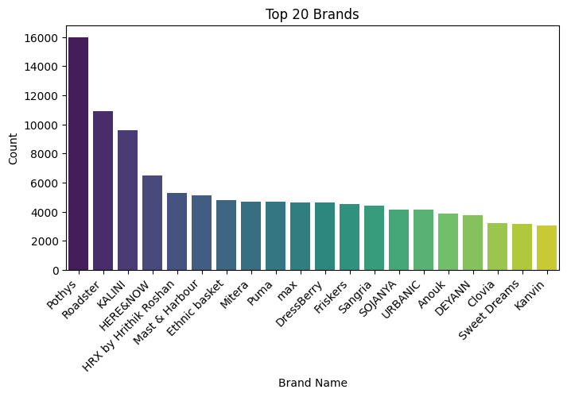

```python
# Visualising the top 20 brands
top_brands = df['BrandName'].value_counts().head(20)

# Plotting the top 20 brands using a barplot with vibrant colors
plt.figure(figsize=(8, 4))
sns.barplot(x=top_brands.index, y=top_brands.values, palette='viridis')
plt.title('Top 20 Brands')
plt.xlabel('Brand Name')
plt.ylabel('Count')
plt.xticks(rotation=45, ha='right')
plt.show()
```

Pothys is the most popular brand followed by Roadster.

### Top 20 individual categories

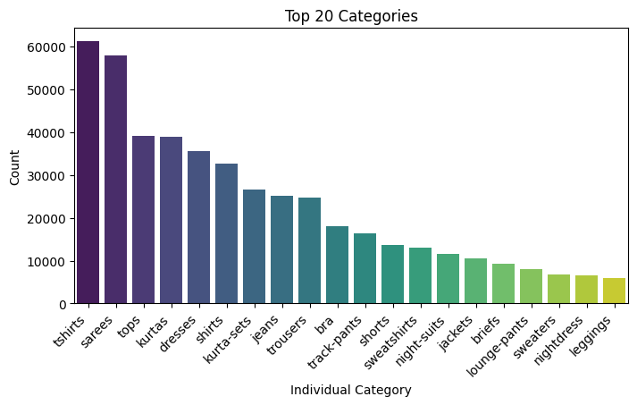

```python
# Visualising the top 20 individual categories
top_brands = df['Individual_category'].value_counts().head(20)

# Plotting the top 20 brands using a barplot with vibrant colors
plt.figure(figsize=(8, 4))
sns.barplot(x=top_brands.index, y=top_brands.values, palette='viridis')
plt.title('Top 20 Categories')
plt.xlabel('Individual Category')
plt.ylabel('Count')
plt.xticks(rotation=45, ha='right')
plt.show()
```

Tshirts are the most bought items, followed by sarees and tops.

[figure not shown]

```python
plt.figure(figsize=(8, 4))
sns.histplot(df['DiscountPrice (in Rs)'], bins=30, kde=True, color='skyblue')
plt.title('Histogram for Original Price')
plt.xlabel('Discount Price (in Rs)')
plt.ylabel('Frequency')
plt.show()
```

Most prices are in the range from 100- 5000. However there are some extreme values.

### Distribution of discounted price

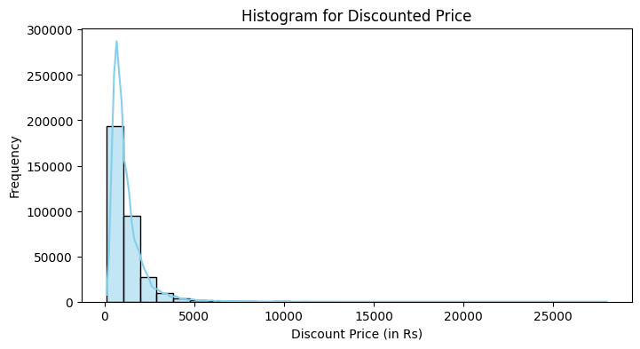

```python
plt.figure(figsize=(8, 4))
sns.histplot(df['DiscountPrice (in Rs)'], bins=30, kde=True, color='skyblue')
plt.title('Histogram for Discounted Price')
plt.xlabel('Discount Price (in Rs)')
plt.ylabel('Frequency')
plt.show()
```

Most prices are in the range from 100- 5000. However there are some extreme values.

### Distribution of ratings

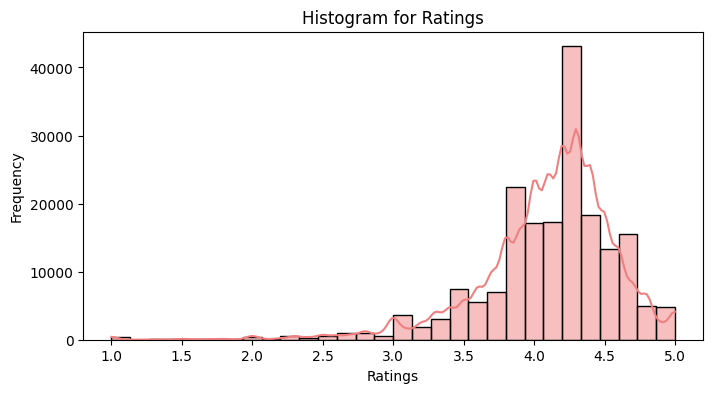

```python
plt.figure(figsize=(8, 4))
sns.histplot(df['Ratings'], bins=30, kde=True, color='lightcoral')
plt.title('Histogram for Ratings')
plt.xlabel('Ratings')
plt.ylabel('Frequency')
plt.show()
```

Most products are rated in the range of 4-4.5.

### Histogram for reviews

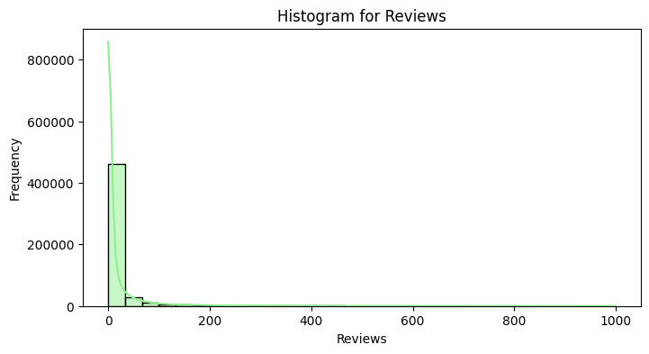

```python
plt.figure(figsize=(8, 4))
sns.histplot(df['Reviews'], bins=30, kde=True, color='lightgreen')
plt.title('Histogram for Reviews')
plt.xlabel('Reviews')
plt.ylabel('Frequency')
plt.show()
```

Most products have reviews in the range of 0-50, but there are a lot of outliers.

### Top 20 Brands by Original Price

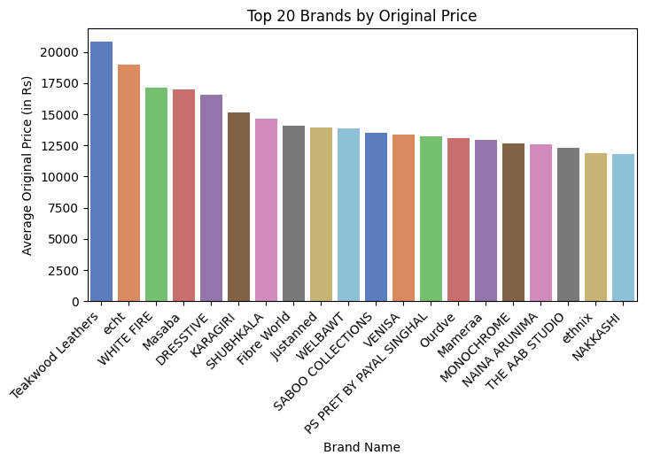

```python
average_price_by_brand = df.groupby('BrandName')['OriginalPrice (in Rs)'].mean()
top_20_brands = average_price_by_brand.nlargest(20)

# Plotting the top 10 brands by original price
plt.figure(figsize=(8, 4))
sns.barplot(x=top_20_brands.index, y=top_20_brands.values, palette='muted')
plt.title('Top 20 Brands by Original Price')
plt.xlabel('Brand Name')
plt.ylabel('Average Original Price (in Rs)')
plt.xticks(rotation=45, ha='right')
plt.show()
```

Teakwood Leathers is the most expensive brand followed b echt and White Fire.

### Top 20 most expensive categories

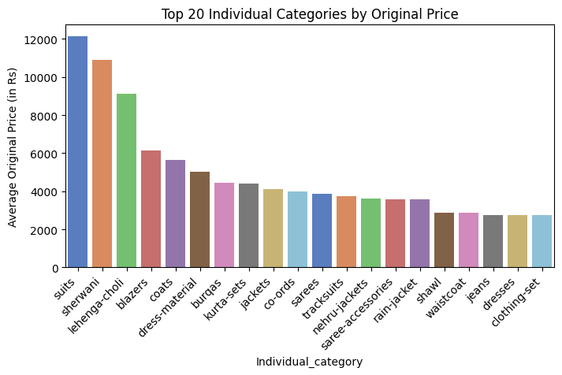

```python
average_price_by_category = df.groupby('Individual_category')['OriginalPrice (in Rs)'].mean()
top_20_categories = average_price_by_category.nlargest(20)

# Plotting the top 20 brands by original price
plt.figure(figsize=(8, 4))
sns.barplot(x=top_20_categories.index, y=top_20_categories.values, palette='muted')
plt.title('Top 20 Individual Categories by Original Price')
plt.xlabel('Individual_category')
plt.ylabel('Average Original Price (in Rs)')
plt.xticks(rotation=45, ha='right')
plt.show()
```

Suits are the most expensive type of clothes followed by sherwani and lehenga-choli.

### Categories for men and women

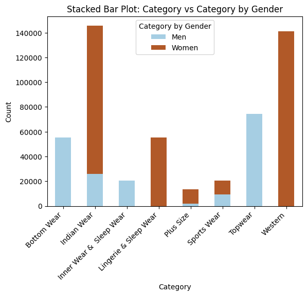

```python
# Create a cross-tabulation to get the counts
cross_tab = pd.crosstab(df['Category'], df['category_by_Gender'])

# Plotting the stacked bar plot
plt.figure(figsize=(12, 6))
cross_tab.plot(kind='bar', stacked=True, colormap='Paired')
plt.title('Stacked Bar Plot: Category vs Category by Gender')
plt.xlabel('Category')
plt.ylabel('Count')
plt.xticks(rotation=45, ha='right')
plt.legend(title='Category by Gender')
plt.show()
```

Bottomwear, innerwear, and topwear are only for men. Lingerine and western wear are only for women. The other categories are available for both genders.

### Correlation heatmap

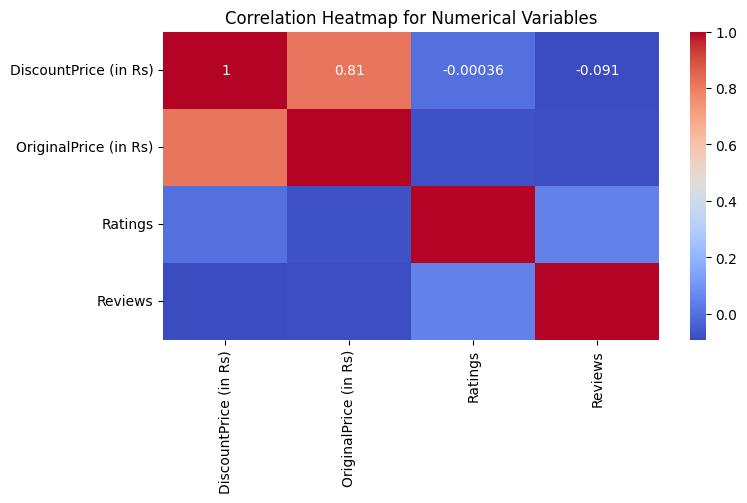

```python
# Select only numerical columns for correlation
numerical_columns = df.select_dtypes(include='number')

# Calculate the correlation matrix
correlation_matrix = numerical_columns.corr()

# Create a heatmap
plt.figure(figsize=(8, 4))
sns.heatmap(correlation_matrix, annot=True, cmap='coolwarm')
plt.title('Correlation Heatmap for Numerical Variables')
plt.show()
```

Original and discounted price are correlated but this is a case of multicollinearity. Other than that, none of the variables are correlated.

After having done enough EDA, we move forward for data preprocessing.

## Data Preprocessing

### Data Engineering

#### Handling the Discount Offer column

We first see if all the values in the discount offer column are given in the same format or not.

```python
trial_check1 = df.iloc[4567]
trial_check1
```

```
BrandName                                               HIGHLANDER
Category                                               Bottom Wear
Individual_category                                       trousers
category_by_Gender                                             Men
Description              highlander men pink slim fit solid chinos
DiscountPrice (in Rs)                                        591.0
OriginalPrice (in Rs)                                       1599.0
DiscountOffer                                              63% OFF
SizeOption                                          30, 32, 34, 36
Ratings                                                        4.1
Reviews                                                      491.0
Name: 4567, dtype: object
```

```python
trial_check2 = df.iloc[199]
trial_check2
```

```
BrandName                                                   Mast & Harbour
Category                                                           Western
Individual_category                                                tshirts
category_by_Gender                                                   Women
Description              mast  harbour women off white striped round ne...
DiscountPrice (in Rs)                                                  NaN
OriginalPrice (in Rs)                                                899.0
DiscountOffer                                                  Rs. 400 OFF
SizeOption                                                 XS, S, M, L, XL
Ratings                                                                4.3
Reviews                                                              961.0
Name: 199, dtype: object
```

It is noticed that in the Discount Offer column, some values are given as "'percentage' OFF" and some are given as "'Rupees' OFF". Since this column is inconsistent, we do some data engineering and created a new column called discount_percentage, where we store the discount percentage as float values and calculate the discount percentage for rows where discount is given in rupees.

```python
# Extract the numerical value from the string and convert it to float and store in a new column DiscountValue
df['DiscountValue'] = df['DiscountOffer'].str.extract('(\d+)').astype(float)
```

```python
 # Create and initialize the new column discount_percentage
df['discount_percentage'] = 0

# Assuming that null values mean no discount given, replace null values in 'DiscountOffer' with 0
df['DiscountOffer'].fillna('0', inplace=True)

# Identify rows where the discount is given in rupees
rupees_discount_rows = df['DiscountOffer'].str.contains('Rs. \d+ OFF')

# Calculate discount percentage for rows with rupees discount
df.loc[rupees_discount_rows, 'discount_percentage'] = (df.loc[rupees_discount_rows, 'DiscountValue'] / df.loc[rupees_discount_rows, 'OriginalPrice (in Rs)']) * 100

# Explicitly cast 'discount_percentage' to float
df['discount_percentage'] = df['discount_percentage'].astype(float)

# For rows where the discount is already in percentage, copy the values directly
percentage_discount_rows = ~rupees_discount_rows
df.loc[percentage_discount_rows, 'discount_percentage'] = df.loc[percentage_discount_rows, 'DiscountValue']

df
```

|  | BrandName | Category | Individual_category | category_by_Gender | Description | DiscountPrice (in Rs) | OriginalPrice (in Rs) | DiscountOffer | SizeOption | Ratings | Reviews | DiscountValue | discount_percentage |
| --- | --- | --- | --- | --- | --- | --- | --- | --- | --- | --- | --- | --- | --- |
| 0 | Roadster | Bottom Wear | jeans | Men | roadster men navy blue slim fit mid rise clean... | 824.0 | 1499.0 | 45% OFF | 28, 30, 32, 34, 36 | 3.9 | 999.0 | 45.0 | 45.0 |
| 1 | LOCOMOTIVE | Bottom Wear | track-pants | Men | locomotive men black white solid slim fit tra... | 517.0 | 1149.0 | 55% OFF | S, M, L, XL | 4.0 | 999.0 | 55.0 | 55.0 |
| 2 | Roadster | Topwear | shirts | Men | roadster men navy white black geometric print... | 629.0 | 1399.0 | 55% OFF | 38, 40, 42, 44, 46, 48 | 4.3 | 999.0 | 55.0 | 55.0 |
| 3 | Zivame | Lingerie & Sleep Wear | shapewear | Women | zivame women black saree shapewear zi3023core0... | 893.0 | 1295.0 | 31% OFF | S, M, L, XL, XXL | 4.2 | 999.0 | 31.0 | 31.0 |
| 4 | Roadster | Western | tshirts | Women | roadster women white solid v neck pure cotton ... | NaN | 599.0 | 35% OFF | XS, S, M, L, XL | 4.2 | 999.0 | 35.0 | 35.0 |
| ... | ... | ... | ... | ... | ... | ... | ... | ... | ... | ... | ... | ... | ... |
| 526559 | H&M | Western | sweaters | Women | hm women beige oversized cashmere jumper | NaN | 9999.0 | 0 | XS, S, M, L | NaN | 0.0 | NaN | NaN |
| 526560 | H&M | Western | jackets | Women | hm women black water repellent parka jacket | NaN | 9999.0 | 0 | XS, S, M, L, XL | NaN | 0.0 | NaN | NaN |
| 526561 | 250 DESIGNS | Western | dresses | Women | 250 designs blue lace sheath dress | NaN | 9999.0 | 0 | S, M, L, XL, XXL | NaN | 0.0 | NaN | NaN |
| 526562 | Masaba | Western | dresses | Women | masaba women yellow printed a line dress | NaN | 9999.0 | 0 | XS, S, M, L, XL | NaN | 0.0 | NaN | NaN |
| 526563 | Jockey | Western | tshirts | Women | jockey women blue extended sleeves t shirt | NaN | 799.0 | 0 | S, M, L | NaN | 0.0 | NaN | NaN |

526564 rows × 13 columns

The discount percentage column was successfully created but there are still null values. We assume that null values indicate that there was no discount given on the specific product. So we replace all the null values with 0.

```python
df['discount_percentage'].fillna(0, inplace=True)
df
```

|  | BrandName | Category | Individual_category | category_by_Gender | Description | DiscountPrice (in Rs) | OriginalPrice (in Rs) | DiscountOffer | SizeOption | Ratings | Reviews | DiscountValue | discount_percentage |
| --- | --- | --- | --- | --- | --- | --- | --- | --- | --- | --- | --- | --- | --- |
| 0 | Roadster | Bottom Wear | jeans | Men | roadster men navy blue slim fit mid rise clean... | 824.0 | 1499.0 | 45% OFF | 28, 30, 32, 34, 36 | 3.9 | 999.0 | 45.0 | 45.0 |
| 1 | LOCOMOTIVE | Bottom Wear | track-pants | Men | locomotive men black white solid slim fit tra... | 517.0 | 1149.0 | 55% OFF | S, M, L, XL | 4.0 | 999.0 | 55.0 | 55.0 |
| 2 | Roadster | Topwear | shirts | Men | roadster men navy white black geometric print... | 629.0 | 1399.0 | 55% OFF | 38, 40, 42, 44, 46, 48 | 4.3 | 999.0 | 55.0 | 55.0 |
| 3 | Zivame | Lingerie & Sleep Wear | shapewear | Women | zivame women black saree shapewear zi3023core0... | 893.0 | 1295.0 | 31% OFF | S, M, L, XL, XXL | 4.2 | 999.0 | 31.0 | 31.0 |
| 4 | Roadster | Western | tshirts | Women | roadster women white solid v neck pure cotton ... | NaN | 599.0 | 35% OFF | XS, S, M, L, XL | 4.2 | 999.0 | 35.0 | 35.0 |
| ... | ... | ... | ... | ... | ... | ... | ... | ... | ... | ... | ... | ... | ... |
| 526559 | H&M | Western | sweaters | Women | hm women beige oversized cashmere jumper | NaN | 9999.0 | 0 | XS, S, M, L | NaN | 0.0 | NaN | 0.0 |
| 526560 | H&M | Western | jackets | Women | hm women black water repellent parka jacket | NaN | 9999.0 | 0 | XS, S, M, L, XL | NaN | 0.0 | NaN | 0.0 |
| 526561 | 250 DESIGNS | Western | dresses | Women | 250 designs blue lace sheath dress | NaN | 9999.0 | 0 | S, M, L, XL, XXL | NaN | 0.0 | NaN | 0.0 |
| 526562 | Masaba | Western | dresses | Women | masaba women yellow printed a line dress | NaN | 9999.0 | 0 | XS, S, M, L, XL | NaN | 0.0 | NaN | 0.0 |
| 526563 | Jockey | Western | tshirts | Women | jockey women blue extended sleeves t shirt | NaN | 799.0 | 0 | S, M, L | NaN | 0.0 | NaN | 0.0 |

526564 rows × 13 columns

```python
check1 = df.iloc[4567]
check1
```

```
BrandName                                               HIGHLANDER
Category                                               Bottom Wear
Individual_category                                       trousers
category_by_Gender                                             Men
Description              highlander men pink slim fit solid chinos
DiscountPrice (in Rs)                                        591.0
OriginalPrice (in Rs)                                       1599.0
DiscountOffer                                              63% OFF
SizeOption                                          30, 32, 34, 36
Ratings                                                        4.1
Reviews                                                      491.0
DiscountValue                                                 63.0
discount_percentage                                           63.0
Name: 4567, dtype: object
```

```python
check2 = df.iloc[199]
check2
```

```
BrandName                                                   Mast & Harbour
Category                                                           Western
Individual_category                                                tshirts
category_by_Gender                                                   Women
Description              mast  harbour women off white striped round ne...
DiscountPrice (in Rs)                                                  NaN
OriginalPrice (in Rs)                                                899.0
DiscountOffer                                                  Rs. 400 OFF
SizeOption                                                 XS, S, M, L, XL
Ratings                                                                4.3
Reviews                                                              961.0
DiscountValue                                                        400.0
discount_percentage                                              44.493882
Name: 199, dtype: object
```

We can see now that the Discount Offer has been uniformly and successfully used to make a new column discount percentage.

We have seen before that in the discount price column, around 1/3rd of the values are missing. But we have the original price and also now we have the discount percentage. So we can calculate the discounted price and store it in a new column.

```python
# Assuming you have columns 'OriginalPrice' and 'DiscountPercentage' in your DataFrame df
df['DiscountedPrice'] = df['OriginalPrice (in Rs)'] - (df['OriginalPrice (in Rs)'] * (df['discount_percentage'] / 100))
df
```

|  | BrandName | Category | Individual_category | category_by_Gender | Description | DiscountPrice (in Rs) | OriginalPrice (in Rs) | DiscountOffer | SizeOption | Ratings | Reviews | DiscountValue | discount_percentage | DiscountedPrice |
| --- | --- | --- | --- | --- | --- | --- | --- | --- | --- | --- | --- | --- | --- | --- |
| 0 | Roadster | Bottom Wear | jeans | Men | roadster men navy blue slim fit mid rise clean... | 824.0 | 1499.0 | 45% OFF | 28, 30, 32, 34, 36 | 3.9 | 999.0 | 45.0 | 45.0 | 824.45 |
| 1 | LOCOMOTIVE | Bottom Wear | track-pants | Men | locomotive men black white solid slim fit tra... | 517.0 | 1149.0 | 55% OFF | S, M, L, XL | 4.0 | 999.0 | 55.0 | 55.0 | 517.05 |
| 2 | Roadster | Topwear | shirts | Men | roadster men navy white black geometric print... | 629.0 | 1399.0 | 55% OFF | 38, 40, 42, 44, 46, 48 | 4.3 | 999.0 | 55.0 | 55.0 | 629.55 |
| 3 | Zivame | Lingerie & Sleep Wear | shapewear | Women | zivame women black saree shapewear zi3023core0... | 893.0 | 1295.0 | 31% OFF | S, M, L, XL, XXL | 4.2 | 999.0 | 31.0 | 31.0 | 893.55 |
| 4 | Roadster | Western | tshirts | Women | roadster women white solid v neck pure cotton ... | NaN | 599.0 | 35% OFF | XS, S, M, L, XL | 4.2 | 999.0 | 35.0 | 35.0 | 389.35 |
| ... | ... | ... | ... | ... | ... | ... | ... | ... | ... | ... | ... | ... | ... | ... |
| 526559 | H&M | Western | sweaters | Women | hm women beige oversized cashmere jumper | NaN | 9999.0 | 0 | XS, S, M, L | NaN | 0.0 | NaN | 0.0 | 9999.00 |
| 526560 | H&M | Western | jackets | Women | hm women black water repellent parka jacket | NaN | 9999.0 | 0 | XS, S, M, L, XL | NaN | 0.0 | NaN | 0.0 | 9999.00 |
| 526561 | 250 DESIGNS | Western | dresses | Women | 250 designs blue lace sheath dress | NaN | 9999.0 | 0 | S, M, L, XL, XXL | NaN | 0.0 | NaN | 0.0 | 9999.00 |
| 526562 | Masaba | Western | dresses | Women | masaba women yellow printed a line dress | NaN | 9999.0 | 0 | XS, S, M, L, XL | NaN | 0.0 | NaN | 0.0 | 9999.00 |
| 526563 | Jockey | Western | tshirts | Women | jockey women blue extended sleeves t shirt | NaN | 799.0 | 0 | S, M, L | NaN | 0.0 | NaN | 0.0 | 799.00 |

526564 rows × 14 columns

We can now drop the Discount Price (in Rs.), DiscountOffer, and DiscountValue.

```python
drop_rep_cols = ['DiscountPrice (in Rs)', 'DiscountOffer', 'DiscountValue']
df.drop(columns=drop_rep_cols, inplace=True)
df
```

|  | BrandName | Category | Individual_category | category_by_Gender | Description | OriginalPrice (in Rs) | SizeOption | Ratings | Reviews | discount_percentage | DiscountedPrice |
| --- | --- | --- | --- | --- | --- | --- | --- | --- | --- | --- | --- |
| 0 | Roadster | Bottom Wear | jeans | Men | roadster men navy blue slim fit mid rise clean... | 1499.0 | 28, 30, 32, 34, 36 | 3.9 | 999.0 | 45.0 | 824.45 |
| 1 | LOCOMOTIVE | Bottom Wear | track-pants | Men | locomotive men black white solid slim fit tra... | 1149.0 | S, M, L, XL | 4.0 | 999.0 | 55.0 | 517.05 |
| 2 | Roadster | Topwear | shirts | Men | roadster men navy white black geometric print... | 1399.0 | 38, 40, 42, 44, 46, 48 | 4.3 | 999.0 | 55.0 | 629.55 |
| 3 | Zivame | Lingerie & Sleep Wear | shapewear | Women | zivame women black saree shapewear zi3023core0... | 1295.0 | S, M, L, XL, XXL | 4.2 | 999.0 | 31.0 | 893.55 |
| 4 | Roadster | Western | tshirts | Women | roadster women white solid v neck pure cotton ... | 599.0 | XS, S, M, L, XL | 4.2 | 999.0 | 35.0 | 389.35 |
| ... | ... | ... | ... | ... | ... | ... | ... | ... | ... | ... | ... |
| 526559 | H&M | Western | sweaters | Women | hm women beige oversized cashmere jumper | 9999.0 | XS, S, M, L | NaN | 0.0 | 0.0 | 9999.00 |
| 526560 | H&M | Western | jackets | Women | hm women black water repellent parka jacket | 9999.0 | XS, S, M, L, XL | NaN | 0.0 | 0.0 | 9999.00 |
| 526561 | 250 DESIGNS | Western | dresses | Women | 250 designs blue lace sheath dress | 9999.0 | S, M, L, XL, XXL | NaN | 0.0 | 0.0 | 9999.00 |
| 526562 | Masaba | Western | dresses | Women | masaba women yellow printed a line dress | 9999.0 | XS, S, M, L, XL | NaN | 0.0 | 0.0 | 9999.00 |
| 526563 | Jockey | Western | tshirts | Women | jockey women blue extended sleeves t shirt | 799.0 | S, M, L | NaN | 0.0 | 0.0 | 799.00 |

526564 rows × 11 columns

Now we check if there are any missing values left to be imputed other than the Ratings.

```python
df.isna().sum()
```

```
BrandName                     0
Category                      0
Individual_category           0
category_by_Gender            0
Description                   0
OriginalPrice (in Rs)         0
SizeOption                    0
Ratings                  336152
Reviews                       0
discount_percentage           0
DiscountedPrice               0
dtype: int64
```

All the missing values have been imputed.

### Further Feature Engineering

#### Converting the size option column to a usable format

The size option contains size options in a single row, in string format.

We cannot directly use this feature to build models. But this feature is necessary since product ratings might be dependent on how many size options are available for the product.

Therefore we create a new column called num_size_options where we convert the string to a set and then return the length of each set, giving the number of unique size options for each row. We do this by using the lambda function.

```python
df['num_size_options']= df['SizeOption'].apply(lambda x: len(set(str(x).split(','))) if pd.notnull(x) else 0)
df
```

|  | BrandName | Category | Individual_category | category_by_Gender | Description | OriginalPrice (in Rs) | SizeOption | Ratings | Reviews | discount_percentage | DiscountedPrice | num_size_options |
| --- | --- | --- | --- | --- | --- | --- | --- | --- | --- | --- | --- | --- |
| 0 | Roadster | Bottom Wear | jeans | Men | roadster men navy blue slim fit mid rise clean... | 1499.0 | 28, 30, 32, 34, 36 | 3.9 | 999.0 | 45.0 | 824.45 | 5 |
| 1 | LOCOMOTIVE | Bottom Wear | track-pants | Men | locomotive men black white solid slim fit tra... | 1149.0 | S, M, L, XL | 4.0 | 999.0 | 55.0 | 517.05 | 4 |
| 2 | Roadster | Topwear | shirts | Men | roadster men navy white black geometric print... | 1399.0 | 38, 40, 42, 44, 46, 48 | 4.3 | 999.0 | 55.0 | 629.55 | 6 |
| 3 | Zivame | Lingerie & Sleep Wear | shapewear | Women | zivame women black saree shapewear zi3023core0... | 1295.0 | S, M, L, XL, XXL | 4.2 | 999.0 | 31.0 | 893.55 | 5 |
| 4 | Roadster | Western | tshirts | Women | roadster women white solid v neck pure cotton ... | 599.0 | XS, S, M, L, XL | 4.2 | 999.0 | 35.0 | 389.35 | 5 |
| ... | ... | ... | ... | ... | ... | ... | ... | ... | ... | ... | ... | ... |
| 526559 | H&M | Western | sweaters | Women | hm women beige oversized cashmere jumper | 9999.0 | XS, S, M, L | NaN | 0.0 | 0.0 | 9999.00 | 4 |
| 526560 | H&M | Western | jackets | Women | hm women black water repellent parka jacket | 9999.0 | XS, S, M, L, XL | NaN | 0.0 | 0.0 | 9999.00 | 5 |
| 526561 | 250 DESIGNS | Western | dresses | Women | 250 designs blue lace sheath dress | 9999.0 | S, M, L, XL, XXL | NaN | 0.0 | 0.0 | 9999.00 | 5 |
| 526562 | Masaba | Western | dresses | Women | masaba women yellow printed a line dress | 9999.0 | XS, S, M, L, XL | NaN | 0.0 | 0.0 | 9999.00 | 5 |
| 526563 | Jockey | Western | tshirts | Women | jockey women blue extended sleeves t shirt | 799.0 | S, M, L | NaN | 0.0 | 0.0 | 799.00 | 3 |

526564 rows × 12 columns

We can now drop the SizeOption column since it is of no use anymore.

```python
df.drop(columns=['SizeOption'], inplace=True)
```

Thus this column has been successfully imputed.

#### Dealing with description

The description is in text format, but we can use it to extract an important feature that is colour of the product. We wil store the colour in a new column.

```python
def extract_color(description):
    color_keywords = ['black', 'blue', 'red', 'green', 'yellow', 'orange', 'purple', 'pink', 'white', 'gray', 'brown']

    # Check if any color keyword is present in the lowercase description
    for color in color_keywords:
        if color in description.lower():
            return color

    return 'unknown'

# Apply the function to the 'Description' column and create a new 'color' column
df['color'] = df['Description'].apply(extract_color)

# Display the resulting DataFrame
df
```

|  | BrandName | Category | Individual_category | category_by_Gender | Description | OriginalPrice (in Rs) | Ratings | Reviews | discount_percentage | DiscountedPrice | num_size_options | color |
| --- | --- | --- | --- | --- | --- | --- | --- | --- | --- | --- | --- | --- |
| 0 | Roadster | Bottom Wear | jeans | Men | roadster men navy blue slim fit mid rise clean... | 1499.0 | 3.9 | 999.0 | 45.0 | 824.45 | 5 | blue |
| 1 | LOCOMOTIVE | Bottom Wear | track-pants | Men | locomotive men black white solid slim fit tra... | 1149.0 | 4.0 | 999.0 | 55.0 | 517.05 | 4 | black |
| 2 | Roadster | Topwear | shirts | Men | roadster men navy white black geometric print... | 1399.0 | 4.3 | 999.0 | 55.0 | 629.55 | 6 | black |
| 3 | Zivame | Lingerie & Sleep Wear | shapewear | Women | zivame women black saree shapewear zi3023core0... | 1295.0 | 4.2 | 999.0 | 31.0 | 893.55 | 5 | black |
| 4 | Roadster | Western | tshirts | Women | roadster women white solid v neck pure cotton ... | 599.0 | 4.2 | 999.0 | 35.0 | 389.35 | 5 | white |
| ... | ... | ... | ... | ... | ... | ... | ... | ... | ... | ... | ... | ... |
| 526559 | H&M | Western | sweaters | Women | hm women beige oversized cashmere jumper | 9999.0 | NaN | 0.0 | 0.0 | 9999.00 | 4 | unknown |
| 526560 | H&M | Western | jackets | Women | hm women black water repellent parka jacket | 9999.0 | NaN | 0.0 | 0.0 | 9999.00 | 5 | black |
| 526561 | 250 DESIGNS | Western | dresses | Women | 250 designs blue lace sheath dress | 9999.0 | NaN | 0.0 | 0.0 | 9999.00 | 5 | blue |
| 526562 | Masaba | Western | dresses | Women | masaba women yellow printed a line dress | 9999.0 | NaN | 0.0 | 0.0 | 9999.00 | 5 | yellow |
| 526563 | Jockey | Western | tshirts | Women | jockey women blue extended sleeves t shirt | 799.0 | NaN | 0.0 | 0.0 | 799.00 | 3 | blue |

526564 rows × 12 columns

Now that we have extracted the colour, we can remove description from our dataset.

```python
df.drop(columns=['Description'], inplace=True)
```

### Grouping categorical variables

```python
categorical_columns = df.select_dtypes(include='object').columns

for column in categorical_columns:
    unique_categories_count = df[column].nunique()
    print(f"Number of unique categories in {column}: {unique_categories_count}")
```

```
Number of unique categories in BrandName: 2088
Number of unique categories in Category: 8
Number of unique categories in Individual_category: 92
Number of unique categories in category_by_Gender: 2
Number of unique categories in color: 12
```

BrandName and Individual_category have too many categories and one hot encoding will excessively increase dimensionality, so we will first try to reduce the dimensions by grouping the categories with less than 1000 frequencies into a new category called "Others".

#### Grouped BrandName

```python
brand_name_counts = df['BrandName'].value_counts()
print(brand_name_counts)
```

```
BrandName
Pothys                   16005
Roadster                 10935
KALINI                    9589
HERE&NOW                  6515
HRX by Hrithik Roshan     5297
                         ...
PIVOTO                       1
PEONY SMART WORLD            1
OFFIRA TEX WORLD             1
Sztori Garfield              1
Geonaute By Decathlon        1
Name: count, Length: 2088, dtype: int64
```

```python
# Identify brands with counts less than 1000
brands_to_group = brand_name_counts[brand_name_counts < 1000].index

# Create a new column 'BrandGrouped' and replace brands with counts less than 1000 with 'Others'
df['BrandGrouped'] = df['BrandName'].apply(lambda x: x if x not in brands_to_group else 'Others')
df
```

|  | BrandName | Category | Individual_category | category_by_Gender | OriginalPrice (in Rs) | Ratings | Reviews | discount_percentage | DiscountedPrice | num_size_options | color | BrandGrouped |
| --- | --- | --- | --- | --- | --- | --- | --- | --- | --- | --- | --- | --- |
| 0 | Roadster | Bottom Wear | jeans | Men | 1499.0 | 3.9 | 999.0 | 45.0 | 824.45 | 5 | blue | Roadster |
| 1 | LOCOMOTIVE | Bottom Wear | track-pants | Men | 1149.0 | 4.0 | 999.0 | 55.0 | 517.05 | 4 | black | Others |
| 2 | Roadster | Topwear | shirts | Men | 1399.0 | 4.3 | 999.0 | 55.0 | 629.55 | 6 | black | Roadster |
| 3 | Zivame | Lingerie & Sleep Wear | shapewear | Women | 1295.0 | 4.2 | 999.0 | 31.0 | 893.55 | 5 | black | Zivame |
| 4 | Roadster | Western | tshirts | Women | 599.0 | 4.2 | 999.0 | 35.0 | 389.35 | 5 | white | Roadster |
| ... | ... | ... | ... | ... | ... | ... | ... | ... | ... | ... | ... | ... |
| 526559 | H&M | Western | sweaters | Women | 9999.0 | NaN | 0.0 | 0.0 | 9999.00 | 4 | unknown | H&M |
| 526560 | H&M | Western | jackets | Women | 9999.0 | NaN | 0.0 | 0.0 | 9999.00 | 5 | black | H&M |
| 526561 | 250 DESIGNS | Western | dresses | Women | 9999.0 | NaN | 0.0 | 0.0 | 9999.00 | 5 | blue | Others |
| 526562 | Masaba | Western | dresses | Women | 9999.0 | NaN | 0.0 | 0.0 | 9999.00 | 5 | yellow | Others |
| 526563 | Jockey | Western | tshirts | Women | 799.0 | NaN | 0.0 | 0.0 | 799.00 | 3 | blue | Jockey |

526564 rows × 12 columns

```python
brand_name_counts = df['BrandGrouped'].value_counts()
print(len(brand_name_counts))
```

```
119
```

The categories have been reduced significantly from 2088 to 119.

Now we can drop the original column from the dataframe.

```python
df.drop(columns=['BrandName'], inplace=True)
df
```

|  | Category | Individual_category | category_by_Gender | OriginalPrice (in Rs) | Ratings | Reviews | discount_percentage | DiscountedPrice | num_size_options | color | BrandGrouped |
| --- | --- | --- | --- | --- | --- | --- | --- | --- | --- | --- | --- |
| 0 | Bottom Wear | jeans | Men | 1499.0 | 3.9 | 999.0 | 45.0 | 824.45 | 5 | blue | Roadster |
| 1 | Bottom Wear | track-pants | Men | 1149.0 | 4.0 | 999.0 | 55.0 | 517.05 | 4 | black | Others |
| 2 | Topwear | shirts | Men | 1399.0 | 4.3 | 999.0 | 55.0 | 629.55 | 6 | black | Roadster |
| 3 | Lingerie & Sleep Wear | shapewear | Women | 1295.0 | 4.2 | 999.0 | 31.0 | 893.55 | 5 | black | Zivame |
| 4 | Western | tshirts | Women | 599.0 | 4.2 | 999.0 | 35.0 | 389.35 | 5 | white | Roadster |
| ... | ... | ... | ... | ... | ... | ... | ... | ... | ... | ... | ... |
| 526559 | Western | sweaters | Women | 9999.0 | NaN | 0.0 | 0.0 | 9999.00 | 4 | unknown | H&M |
| 526560 | Western | jackets | Women | 9999.0 | NaN | 0.0 | 0.0 | 9999.00 | 5 | black | H&M |
| 526561 | Western | dresses | Women | 9999.0 | NaN | 0.0 | 0.0 | 9999.00 | 5 | blue | Others |
| 526562 | Western | dresses | Women | 9999.0 | NaN | 0.0 | 0.0 | 9999.00 | 5 | yellow | Others |
| 526563 | Western | tshirts | Women | 799.0 | NaN | 0.0 | 0.0 | 799.00 | 3 | blue | Jockey |

526564 rows × 11 columns

#### Grouping Individual category

We group the individual categrories in a similar manner.

```python
indiv_category_counts = df['Individual_category'].value_counts()
indiv_category_counts
```

```
Individual_category
tshirts           61198
sarees            57915
tops              39126
kurtas            38984
dresses           35590
                  ...
jewellery-set         2
hair-accessory        1
lungi                 1
bracelet              1
flip-flops            1
Name: count, Length: 92, dtype: int64
```

```python
# Identify categories with counts less than 1000
categories_to_group = indiv_category_counts[indiv_category_counts < 1000].index

# Create a new column 'CatGrouped' and replace categories with counts less than 1000 with 'Others'
df['IndivCatGrouped'] = df['Individual_category'].apply(lambda x: x if x not in categories_to_group else 'Others')

# Print the result
df
```

|  | Category | Individual_category | category_by_Gender | OriginalPrice (in Rs) | Ratings | Reviews | discount_percentage | DiscountedPrice | num_size_options | color | BrandGrouped | IndivCatGrouped |
| --- | --- | --- | --- | --- | --- | --- | --- | --- | --- | --- | --- | --- |
| 0 | Bottom Wear | jeans | Men | 1499.0 | 3.9 | 999.0 | 45.0 | 824.45 | 5 | blue | Roadster | jeans |
| 1 | Bottom Wear | track-pants | Men | 1149.0 | 4.0 | 999.0 | 55.0 | 517.05 | 4 | black | Others | track-pants |
| 2 | Topwear | shirts | Men | 1399.0 | 4.3 | 999.0 | 55.0 | 629.55 | 6 | black | Roadster | shirts |
| 3 | Lingerie & Sleep Wear | shapewear | Women | 1295.0 | 4.2 | 999.0 | 31.0 | 893.55 | 5 | black | Zivame | Others |
| 4 | Western | tshirts | Women | 599.0 | 4.2 | 999.0 | 35.0 | 389.35 | 5 | white | Roadster | tshirts |
| ... | ... | ... | ... | ... | ... | ... | ... | ... | ... | ... | ... | ... |
| 526559 | Western | sweaters | Women | 9999.0 | NaN | 0.0 | 0.0 | 9999.00 | 4 | unknown | H&M | sweaters |
| 526560 | Western | jackets | Women | 9999.0 | NaN | 0.0 | 0.0 | 9999.00 | 5 | black | H&M | jackets |
| 526561 | Western | dresses | Women | 9999.0 | NaN | 0.0 | 0.0 | 9999.00 | 5 | blue | Others | dresses |
| 526562 | Western | dresses | Women | 9999.0 | NaN | 0.0 | 0.0 | 9999.00 | 5 | yellow | Others | dresses |
| 526563 | Western | tshirts | Women | 799.0 | NaN | 0.0 | 0.0 | 799.00 | 3 | blue | Jockey | tshirts |

526564 rows × 12 columns

```python
top_brand_name_counts = df['IndivCatGrouped'].value_counts()
print(len(top_brand_name_counts))
```

```
43
```

The categories have been reduced significantly to 43.

We can now drop the original column from the dataset.

```python
df.drop(columns=['Individual_category'], inplace=True)
df
```

|  | Category | category_by_Gender | OriginalPrice (in Rs) | Ratings | Reviews | discount_percentage | DiscountedPrice | num_size_options | color | BrandGrouped | IndivCatGrouped |
| --- | --- | --- | --- | --- | --- | --- | --- | --- | --- | --- | --- |
| 0 | Bottom Wear | Men | 1499.0 | 3.9 | 999.0 | 45.0 | 824.45 | 5 | blue | Roadster | jeans |
| 1 | Bottom Wear | Men | 1149.0 | 4.0 | 999.0 | 55.0 | 517.05 | 4 | black | Others | track-pants |
| 2 | Topwear | Men | 1399.0 | 4.3 | 999.0 | 55.0 | 629.55 | 6 | black | Roadster | shirts |
| 3 | Lingerie & Sleep Wear | Women | 1295.0 | 4.2 | 999.0 | 31.0 | 893.55 | 5 | black | Zivame | Others |
| 4 | Western | Women | 599.0 | 4.2 | 999.0 | 35.0 | 389.35 | 5 | white | Roadster | tshirts |
| ... | ... | ... | ... | ... | ... | ... | ... | ... | ... | ... | ... |
| 526559 | Western | Women | 9999.0 | NaN | 0.0 | 0.0 | 9999.00 | 4 | unknown | H&M | sweaters |
| 526560 | Western | Women | 9999.0 | NaN | 0.0 | 0.0 | 9999.00 | 5 | black | H&M | jackets |
| 526561 | Western | Women | 9999.0 | NaN | 0.0 | 0.0 | 9999.00 | 5 | blue | Others | dresses |
| 526562 | Western | Women | 9999.0 | NaN | 0.0 | 0.0 | 9999.00 | 5 | yellow | Others | dresses |
| 526563 | Western | Women | 799.0 | NaN | 0.0 | 0.0 | 799.00 | 3 | blue | Jockey | tshirts |

526564 rows × 11 columns

## EDA for the new feature engineered columns

### Histogram of discount percentage

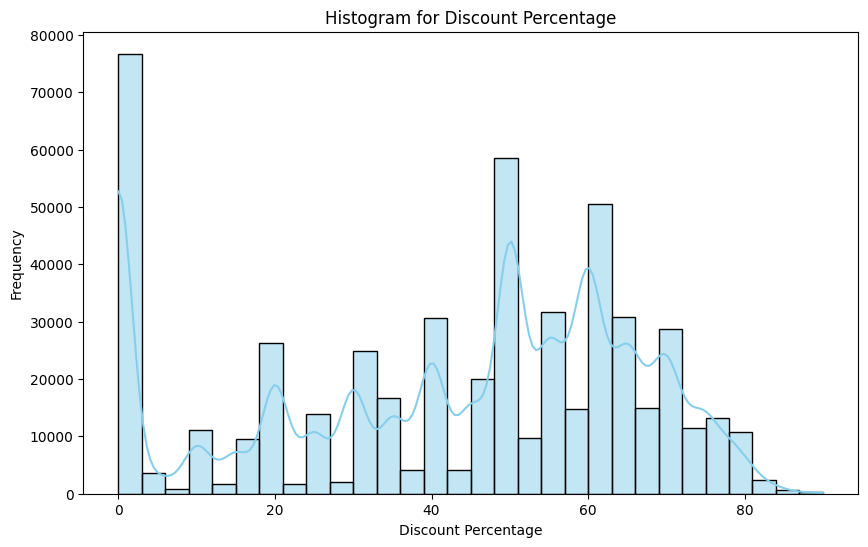

```python
# Plotting the histogram for 'discount_percentage'
plt.figure(figsize=(10, 6))
sns.histplot(df['discount_percentage'], bins=30, kde=True, color='skyblue')
plt.title('Histogram for Discount Percentage')
plt.xlabel('Discount Percentage')
plt.ylabel('Frequency')
plt.show()
```

Many products weren't given a discount. Otherwise, the mean discount ranges between 40-70%.

### Distribution of colour

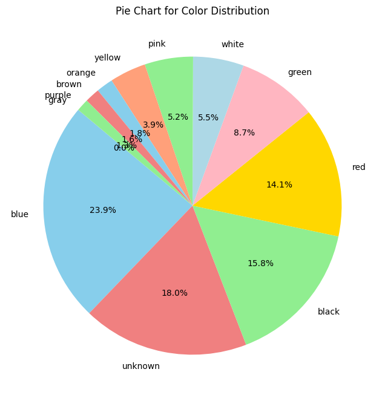

```python
# Calculate the counts of each color
color_counts = df['color'].value_counts()

# Define a custom list of colors
custom_colors = ['skyblue', 'lightcoral', 'lightgreen', 'gold', 'lightpink', 'lightblue', 'lightgreen', 'lightsalmon']

# Plotting the pie chart with different colors
plt.figure(figsize=(8, 8))
plt.pie(color_counts, labels=color_counts.index, autopct='%1.1f%%', colors=custom_colors, startangle=140)
plt.title('Pie Chart for Color Distribution')
plt.show()
```

Blue is the most popular colour followed by black and red.

## Further Data Preprocessing

### Imputing the missing values in Ratings

In this approach, we first use the data for which ratings are available, and then use XGBoost to make predictions for ratings. We will then impute the null values with these predictions.

```python
from xgboost import XGBRegressor
from sklearn.model_selection import train_test_split
from sklearn.preprocessing import LabelEncoder
```

```python
# Separate the data into two sets: one with non-null 'Ratings' and one with null 'Ratings'
df_non_null = df.dropna(subset=['Ratings'])
df_null = df[df['Ratings'].isnull()]
```

```python
# Separate features and target variable for non-null 'Ratings'
X_non_null = df_non_null.drop(['Ratings'], axis=1)
y_non_null = df_non_null['Ratings']
```

```python
# Encode categorical features
label_encoders = {}
for column in X_non_null.select_dtypes(include=['object']).columns:
    le = LabelEncoder()
    X_non_null[column] = le.fit_transform(X_non_null[column])
    label_encoders[column] = le
```

```python
X_train, X_test, y_train, y_test = train_test_split(X_non_null, y_non_null, test_size=0.2, random_state=42)
```

```python
model = XGBRegressor()
model.fit(X_train, y_train)

# Evaluate the model on the test set
mse = np.mean((model.predict(X_test) - y_test) ** 2)
print(f'Mean Squared Error: {mse:.2f}')
```

```
Mean Squared Error: 0.22
```

```python
# Prepare data for null 'Ratings' values
X_null = df_null.drop(['Ratings'], axis=1)

# Encode categorical features for the null values
for column, le in label_encoders.items():
    X_null[column] = le.transform(X_null[column])

# Predict 'Ratings' for null values
imputed_values = model.predict(X_null)

# Update the original DataFrame with the imputed values
df.loc[df['Ratings'].isnull(), 'Ratings'] = imputed_values
```

```python
df
```

|  | Category | category_by_Gender | OriginalPrice (in Rs) | Ratings | Reviews | discount_percentage | DiscountedPrice | num_size_options | color | BrandGrouped | IndivCatGrouped |
| --- | --- | --- | --- | --- | --- | --- | --- | --- | --- | --- | --- |
| 0 | Bottom Wear | Men | 1499.0 | 3.900000 | 999.0 | 45.0 | 824.45 | 5 | blue | Roadster | jeans |
| 1 | Bottom Wear | Men | 1149.0 | 4.000000 | 999.0 | 55.0 | 517.05 | 4 | black | Others | track-pants |
| 2 | Topwear | Men | 1399.0 | 4.300000 | 999.0 | 55.0 | 629.55 | 6 | black | Roadster | shirts |
| 3 | Lingerie & Sleep Wear | Women | 1295.0 | 4.200000 | 999.0 | 31.0 | 893.55 | 5 | black | Zivame | Others |
| 4 | Western | Women | 599.0 | 4.200000 | 999.0 | 35.0 | 389.35 | 5 | white | Roadster | tshirts |
| ... | ... | ... | ... | ... | ... | ... | ... | ... | ... | ... | ... |
| 526559 | Western | Women | 9999.0 | 3.342295 | 0.0 | 0.0 | 9999.00 | 4 | unknown | H&M | sweaters |
| 526560 | Western | Women | 9999.0 | 3.071898 | 0.0 | 0.0 | 9999.00 | 5 | black | H&M | jackets |
| 526561 | Western | Women | 9999.0 | 2.388466 | 0.0 | 0.0 | 9999.00 | 5 | blue | Others | dresses |
| 526562 | Western | Women | 9999.0 | 2.114774 | 0.0 | 0.0 | 9999.00 | 5 | yellow | Others | dresses |
| 526563 | Western | Women | 799.0 | 3.932324 | 0.0 | 0.0 | 799.00 | 3 | blue | Jockey | tshirts |

526564 rows × 11 columns

The ratings have been imputed